# Notebook

```python
def desc(df, nvalues=10):
    for var in df.columns:
        print ">>> %s" % var
        print "(missing: %d)" % df[var].isnull().sum()
        if df[var].unique().size <= nvalues:
            print df[var].value_counts()
        else:
            print df[var].describe()
        print ""
```

```python
import numpy as np
import pandas as pd
import matplotlib.pyplot as plt
from scipy import stats
from pylab import *
import statsmodels.formula.api as smf
%matplotlib inline
```

## Clean IPEDS Data

```python
ipeds = pd.read_csv('data/ipeds2012/CSV_512014-1015/CSV_512014-1015.csv')
ipeds2 = pd.read_csv('data/ipeds2012/CSV_512014-1002/CSV_512014-1002.csv')
#ipeds = pd.merge(ipeds, pd.read_csv('data/ipeds2012/CSV_512014-1002/CSV_512014-1002.csv'), on='unitid name')
```

```python
rename_map = {'DRVIC2012.Percent admitted - total': 'admit_pct',
              'DRVIC2012.Admissions yield - total': 'admit_yield',
              'DRVIC2012.Tuition and fees, 2012-13': 'tuition_fees',
              'HD2012.Institution size category': 'size_cat',
              'HD2012.Geographic region': 'region',
              'HD2012.Sector of institution': 'inst_sector',
              'HD2012.Level of institution': 'inst_lvl',
              'HD2012.Control of institution': 'inst_ctrl',
              #'HD2012.Degree-granting status': 'degree_grt_status',
              'HD2012.Historically Black College or University': 'hbcu',
              'HD2012.Degree of urbanization (Urban-centric locale)': 'urban',
              'HD2012.Institutional category': 'inst_cat',
              'DRVEF2012.Undergraduate enrollment': 'ug_enrol',
              'DRVEF2012.Graduate enrollment': 'grad_enrol',
              'DRVEF2012.Full-time undergraduate enrollment': 'ft_ug_enrol',
              'DRVEF2012.Part-time undergraduate enrollment': 'pt_ug_enrol',
              'DRVEF2012.Percent of total enrollment that are Black or African American': 'pct_black',
              'DRVEF2012.Percent of total enrollment that are Hispanic/Latino': 'pct_latino',
              'DRVEF2012.Percent of total enrollment that are White': 'pct_white',
              'DRVEF2012.Percent of total enrollment that are Race/ethnicity unknown': 'pct_unknown_race',
              'DRVEF2012.Percent of total enrollment that are women': 'pct_female',
              'EF2012D.Student-to-faculty ratio': 'stud_fac_ratio',
              'EF2012D.Full-time retention rate, 2012': 'ft_reten_rate',
              'EF2012D.Part-time retention rate, 2012': 'pt_reten_rate',
              'DRVEF2012.Percent of undergraduate enrollment 18-24': 'pct_ug_18_24',
              'DRVEF2012.Percent of undergraduate enrollment, 25-64': 'pct_ug_25_64',
              'DRVEF2012.Percent of undergraduate enrollment over 65': 'pct_ug_65p',
              'DRVEFDE2012.Percent of students enrolled exclusively in distance education courses': 'pct_all_dist_ed',
              'DRVEFDE2012.Percent of students enrolled in some but not all distance education courses': 'pct_any_dist_ed',
              'DRVEFDE2012.Percent of students not enrolled in any distance education courses': 'pct_no_dist_ed',
              'DRVGR2012.Graduation rate, total cohort': 'grad_rate',
              'DRVGR2012.Transfer-out rate, total cohort': 'transfer_rate',
              'GR200_12.Graduation rate - degree/certificate within 100% of normal time': 'grad_ontime_rate',
              'SFA1112.Percent of full-time first-time undergraduates receiving any financial aid': 'pct_fin_aid',
              'SFA1112.Average amount of federal, state, local or institutional grant aid received': 'mean_fin_aid',
              'DRVF2012.Core revenues, total dollars (GASB)': 'revenues_public',
              'DRVF2012.Tuition and fees as a percent of core revenues (GASB)': 'tuition_pct_rev_public',
              'DRVF2012.Core revenues, total dollars (FASB)': 'revenues_private',
              'DRVF2012.Tuition and fees as a percent of core revenues (FASB)': 'tuition_pct_rev_private',
              'DRVF2012.Revenues from tuition and fees per FTE (GASB)': 'tuit_rev_per_fte_public',
              'DRVF2012.Revenues from tuition and fees per FTE (FASB)': 'tuit_rev_per_fte_private',
              'DRVF2012.Core expenses, total dollars (GASB)': 'expen_public',
              'DRVF2012.Instruction expenses as a percent of total core expenses (GASB)': 'expen_pct_instr_public',
              'DRVF2012.Academic support expenses as a percent of total core expenses (GASB)': 'expen_pct_acadsup_public',
              'DRVF2012.Core expenses, total dollars (FASB)': 'expen_private',
              'DRVF2012.Instruction expenses as a percent of total core expenses (FASB)': 'expen_pct_instr_private',
              'DRVF2012.Academic support expenses as a percent of total core expenses (FASB)': 'expen_pct_acadsup_private',
              'DRVF2012.Instruction expenses per FTE  (GASB)': 'instr_expen_per_fte_public',
              'DRVF2012.Instruction expenses per FTE  (FASB)': 'instr_expen_per_fte_private',
              'DRVF2012.Salaries, wages, and benefit expenses for core expenses as a percent of total core expenses (GASB)':
                  'expen_pct_labor_public',
              'DRVF2012.Salaries, wages, and benefit expenses for instruction as a percent of total expenses for instruction (GASB)':
                  'expen_pct_instlabor_public',
              'DRVF2012.Salaries, wages, and benefit expenses for core expenses as a percent of total core expenses (FASB)':
                  'expen_pct_labor_private',
              'DRVF2012.Salaries, wages, and benefit expenses for instruction as a percent of total expenses for instruction (FASB)':
                  'expen_pct_instlabor_private',
              'DRVF2012.Endowment assets (year end) per FTE enrollment (GASB)': 'endow_per_fte_public',
              'DRVF2012.Endowment assets (year end) per FTE enrollment (FASB)': 'endow_per_fte_private',
              'DRVHR2012.Average salary equated to 9 months of full-time instructional staff - all ranks': 'mean_ft_sal_all',
              'DRVHR2012.Average salary equated to 9 months of full-time insructional staff - professors': 'mean_ft_sal_prof',
              'DRVHR2012.Average salary equated to 9 months of full-time instructional staff - associate professors': 'mean_ft_sal_assoc',
              'DRVHR2012.Average salary equated to 9 months of full-time instructional staff - assistant professors': 'mean_ft_sal_assis',
              'DRVHR2012.Average salary equated to 9 months of full-time instructional staff - instructors': 'mean_ft_sal_instr',
              'DRVHR2012.Average salary equated to 9 months of full-time instructional staff - lecturers': 'mean_ft_sal_lect',
              'DRVHR2012.Average salary equated to 9 months of full-time instructional staff - No academic rank': 'mean_ft_sal_norank',
              'DRVHR2012.Total FTE staff': 'total_staff_fte',
              'DRVHR2012.Postsecondary Teachers FTE staff': 'teachers_fte',
              'DRVHR2012.Postsecondary Teachers Instructional FTE': 'teach_instr_fte',
              'DRVHR2012.Management FTE': 'manag_fte'}
ipeds.rename(columns=rename_map, inplace=True)
ipeds = ipeds.set_index(['unitid', 'institution name'])[rename_map.values()] # keep only the renamed vars
ipeds.info()
```

```
<class 'pandas.core.frame.DataFrame'>
MultiIndex: 7330 entries, (100654, Alabama A & M University) to (480569, Florida Institute of Technology-Florida Tech Online)
Data columns (total 65 columns):
hbcu                           7330 non-null object
pct_unknown_race               7249 non-null float64
pt_reten_rate                  3673 non-null float64
expen_pct_labor_private        1866 non-null float64
transfer_rate                  2223 non-null float64
endow_per_fte_private          1409 non-null float64
pct_ug_18_24                   3179 non-null float64
expen_pct_instr_public         2003 non-null float64
mean_ft_sal_norank             1307 non-null float64
tuition_pct_rev_public         2003 non-null float64
tuition_fees                   4166 non-null float64
instr_expen_per_fte_public     1936 non-null float64
manag_fte                      7330 non-null int64
ft_reten_rate                  6160 non-null float64
pct_ug_25_64                   3179 non-null float64
tuit_rev_per_fte_private       1863 non-null float64
pct_latino                     7249 non-null float64
expen_pct_instlabor_public     1968 non-null float64
tuit_rev_per_fte_public        1936 non-null float64
total_staff_fte                7330 non-null int64
size_cat                       7330 non-null object
mean_ft_sal_assis              2361 non-null float64
grad_enrol                     7249 non-null float64
urban                          7330 non-null object
pt_ug_enrol                    7249 non-null float64
mean_fin_aid                   6624 non-null float64
teachers_fte                   7330 non-null int64
revenues_public                2004 non-null float64
ft_ug_enrol                    7249 non-null float64
pct_ug_65p                     3179 non-null float64
teach_instr_fte                7330 non-null int64
instr_expen_per_fte_private    1863 non-null float64
inst_sector                    7330 non-null object
expen_private                  1867 non-null float64
expen_pct_acadsup_public       2003 non-null float64
pct_female                     7249 non-null float64
endow_per_fte_public           1237 non-null float64
```

[output cut: 14 more lines]

```
stud_fac_ratio                 6929 non-null float64
pct_no_dist_ed                 7249 non-null float64
pct_black                      7249 non-null float64
expen_pct_labor_public         2003 non-null float64
expen_pct_instr_private        1866 non-null float64
inst_ctrl                      7330 non-null object
revenues_private               1867 non-null float64
grad_rate                      6209 non-null float64
mean_ft_sal_prof               2459 non-null float64
tuition_pct_rev_private        1860 non-null float64
expen_pct_instlabor_private    1862 non-null float64
mean_ft_sal_instr              2966 non-null float64
pct_any_dist_ed                7249 non-null float64
pct_fin_aid                    6670 non-null float64
dtypes: float64(53), int64(4), object(8)
```

```python
ipeds2 = ipeds2[ipeds2['S2012_OC.Occupation and full- and part-time status'] ==
                'Part-time, Instructional staff']
```

```python
ipeds2['pt_teachers'] = ipeds2['S2012_OC.Grand total']
ipeds2['pt_teachers_pct_female'] = ipeds2['S2012_OC.Grand total women'] / ipeds2['pt_teachers']
ipeds2['pt_teachers_pct_white'] = ipeds2['S2012_OC.White total'] / ipeds2['pt_teachers']
ipeds2['pt_teachers_pct_black'] = ipeds2['S2012_OC.Black or African American total'] / ipeds2['pt_teachers']
ipeds2['pt_teachers_pct_latino'] = ipeds2['S2012_OC.Hispanic or Latino total'] / ipeds2['pt_teachers']
ipeds2['pt_teachers_pct_other'] = (ipeds2['pt_teachers']
                                   - ipeds2['S2012_OC.White total']
                                   - ipeds2['S2012_OC.Black or African American total']
                                   - ipeds2['S2012_OC.Hispanic or Latino total']) / ipeds2['pt_teachers']
ipeds2 = ipeds2.set_index(['unitid','institution name']).filter(like='pt_teachers')
ipeds2.info()
```

```
<class 'pandas.core.frame.DataFrame'>
MultiIndex: 3087 entries, (100706, University of Alabama in Huntsville) to (480569, Florida Institute of Technology-Florida Tech Online)
Data columns (total 6 columns):
pt_teachers               3087 non-null int64
pt_teachers_pct_female    3087 non-null float64
pt_teachers_pct_white     3087 non-null float64
pt_teachers_pct_black     3087 non-null float64
pt_teachers_pct_latino    3087 non-null float64
pt_teachers_pct_other     3087 non-null float64
dtypes: float64(5), int64(1)
```

```python
ipeds = pd.merge(ipeds, ipeds2, how='left', left_index=True, right_index=True)
ipeds.info()
```

```
<class 'pandas.core.frame.DataFrame'>
MultiIndex: 7330 entries, (100654, Alabama A & M University) to (480569, Florida Institute of Technology-Florida Tech Online)
Data columns (total 71 columns):
hbcu                           7330 non-null object
pct_unknown_race               7249 non-null float64
pt_reten_rate                  3673 non-null float64
expen_pct_labor_private        1866 non-null float64
transfer_rate                  2223 non-null float64
endow_per_fte_private          1409 non-null float64
pct_ug_18_24                   3179 non-null float64
expen_pct_instr_public         2003 non-null float64
mean_ft_sal_norank             1307 non-null float64
tuition_pct_rev_public         2003 non-null float64
tuition_fees                   4166 non-null float64
instr_expen_per_fte_public     1936 non-null float64
manag_fte                      7330 non-null int64
ft_reten_rate                  6160 non-null float64
pct_ug_25_64                   3179 non-null float64
tuit_rev_per_fte_private       1863 non-null float64
pct_latino                     7249 non-null float64
expen_pct_instlabor_public     1968 non-null float64
tuit_rev_per_fte_public        1936 non-null float64
total_staff_fte                7330 non-null int64
size_cat                       7330 non-null object
mean_ft_sal_assis              2361 non-null float64
grad_enrol                     7249 non-null float64
urban                          7330 non-null object
pt_ug_enrol                    7249 non-null float64
mean_fin_aid                   6624 non-null float64
teachers_fte                   7330 non-null int64
revenues_public                2004 non-null float64
ft_ug_enrol                    7249 non-null float64
pct_ug_65p                     3179 non-null float64
teach_instr_fte                7330 non-null int64
instr_expen_per_fte_private    1863 non-null float64
inst_sector                    7330 non-null object
expen_private                  1867 non-null float64
expen_pct_acadsup_public       2003 non-null float64
pct_female                     7249 non-null float64
endow_per_fte_public           1237 non-null float64
```

[output cut: 20 more lines]

```
revenues_private               1867 non-null float64
grad_rate                      6209 non-null float64
mean_ft_sal_prof               2459 non-null float64
tuition_pct_rev_private        1860 non-null float64
expen_pct_instlabor_private    1862 non-null float64
mean_ft_sal_instr              2966 non-null float64
pct_any_dist_ed                7249 non-null float64
pct_fin_aid                    6670 non-null float64
pt_teachers                    3087 non-null float64
pt_teachers_pct_female         3087 non-null float64
pt_teachers_pct_white          3087 non-null float64
pt_teachers_pct_black          3087 non-null float64
pt_teachers_pct_latino         3087 non-null float64
pt_teachers_pct_other          3087 non-null float64
dtypes: float64(59), int64(4), object(8)
```

```python
df = pd.merge(pd.read_csv('data/adjunct.csv'), ipeds.reset_index(), how='left', left_on='college_unit_id', right_on='unitid')
df.info()
```

```
<class 'pandas.core.frame.DataFrame'>
Int64Index: 6929 entries, 0 to 6928
Data columns (total 108 columns):
department_id                    int64
payaverage                       int64
paytype                          float64
user_supplied_department_name    object
course_type                      float64
contract_type                    object
period_term                      float64
period_year                      float64
has_contract                     float64
has_retirement                   float64
has_health_insurance             float64
has_governance                   float64
has_union                        float64
union_name                       object
is_school_rep                    int64
course_syllabus                  float64
office_space                     float64
student_evals                    float64
has_advanced_degree              float64
paytype_credits                  float64
paytype_class_size               float64
paytype_hours                    float64
paytype_weeks                    float64
paytype_courses                  float64
department_type_id               int64
display_name                     object
department_type_name             object
college_class                    object
college_carnegie                 object
college_unit_id                  int64
college_state                    object
college_id                       int64
college_hbcu                     float64
college_flagship                 float64
college_name                     object
unitid                           float64
institution name                 object
```

[output cut: 57 more lines]

```
revenues_private                 float64
grad_rate                        float64
mean_ft_sal_prof                 float64
tuition_pct_rev_private          float64
expen_pct_instlabor_private      float64
mean_ft_sal_instr                float64
pct_any_dist_ed                  float64
pct_fin_aid                      float64
pt_teachers                      float64
pt_teachers_pct_female           float64
pt_teachers_pct_white            float64
pt_teachers_pct_black            float64
pt_teachers_pct_latino           float64
pt_teachers_pct_other            float64
dtypes: float64(84), int64(6), object(18)
```

### Remove empty/unnecessary variables

```python
df = df.drop(['has_contract', 'college_hbcu', 'college_flagship'], axis=1) # completely empty
df = df.drop(df.filter(like='paytype').columns, axis=1) # no longer kept in new version, very few values
df = df.drop(['college_class', 'college_carnegie'], axis=1) # the fields from IPEDS are higher quality
df = df.drop(['institution name', 'user_supplied_department_name', 'display_name'], axis=1)
df.info()
```

```
<class 'pandas.core.frame.DataFrame'>
Int64Index: 6929 entries, 0 to 6928
Data columns (total 94 columns):
department_id                  6929 non-null int64
payaverage                     6929 non-null int64
course_type                    1471 non-null float64
contract_type                  1724 non-null object
period_term                    4517 non-null float64
period_year                    4517 non-null float64
has_retirement                 6224 non-null float64
has_health_insurance           6249 non-null float64
has_governance                 6202 non-null float64
has_union                      5797 non-null float64
union_name                     4348 non-null object
is_school_rep                  6929 non-null int64
course_syllabus                4503 non-null float64
office_space                   4429 non-null float64
student_evals                  3857 non-null float64
has_advanced_degree            4532 non-null float64
department_type_id             6929 non-null int64
department_type_name           6929 non-null object
college_unit_id                6929 non-null int64
college_state                  6929 non-null object
college_id                     6929 non-null int64
college_name                   6929 non-null object
unitid                         6876 non-null float64
hbcu                           6876 non-null object
pct_unknown_race               6848 non-null float64
pt_reten_rate                  5412 non-null float64
expen_pct_labor_private        2595 non-null float64
transfer_rate                  3837 non-null float64
endow_per_fte_private          2552 non-null float64
pct_ug_18_24                   5197 non-null float64
expen_pct_instr_public         3906 non-null float64
mean_ft_sal_norank             2549 non-null float64
tuition_pct_rev_public         3906 non-null float64
tuition_fees                   6789 non-null float64
instr_expen_per_fte_public     3881 non-null float64
manag_fte                      6876 non-null float64
ft_reten_rate                  6633 non-null float64
```

[output cut: 43 more lines]

```
revenues_private               2595 non-null float64
grad_rate                      6769 non-null float64
mean_ft_sal_prof               5771 non-null float64
tuition_pct_rev_private        2595 non-null float64
expen_pct_instlabor_private    2595 non-null float64
mean_ft_sal_instr              5126 non-null float64
pct_any_dist_ed                6848 non-null float64
pct_fin_aid                    6810 non-null float64
pt_teachers                    4790 non-null float64
pt_teachers_pct_female         4790 non-null float64
pt_teachers_pct_white          4790 non-null float64
pt_teachers_pct_black          4790 non-null float64
pt_teachers_pct_latino         4790 non-null float64
pt_teachers_pct_other          4790 non-null float64
dtypes: float64(75), int64(6), object(13)
```

```python
df = df.sort(axis=1) # sort by column name
df.info()
```

```
<class 'pandas.core.frame.DataFrame'>
Int64Index: 6929 entries, 0 to 6928
Data columns (total 94 columns):
admit_pct                      4597 non-null float64
admit_yield                    4597 non-null float64
college_id                     6929 non-null int64
college_name                   6929 non-null object
college_state                  6929 non-null object
college_unit_id                6929 non-null int64
contract_type                  1724 non-null object
course_syllabus                4503 non-null float64
course_type                    1471 non-null float64
department_id                  6929 non-null int64
department_type_id             6929 non-null int64
department_type_name           6929 non-null object
endow_per_fte_private          2552 non-null float64
endow_per_fte_public           3456 non-null float64
expen_pct_acadsup_private      2595 non-null float64
expen_pct_acadsup_public       3906 non-null float64
expen_pct_instlabor_private    2595 non-null float64
expen_pct_instlabor_public     3904 non-null float64
expen_pct_instr_private        2595 non-null float64
expen_pct_instr_public         3906 non-null float64
expen_pct_labor_private        2595 non-null float64
expen_pct_labor_public         3906 non-null float64
expen_private                  2595 non-null float64
expen_public                   3906 non-null float64
ft_reten_rate                  6633 non-null float64
ft_ug_enrol                    6848 non-null float64
grad_enrol                     6848 non-null float64
grad_ontime_rate               1669 non-null float64
grad_rate                      6769 non-null float64
has_advanced_degree            4532 non-null float64
has_governance                 6202 non-null float64
has_health_insurance           6249 non-null float64
has_retirement                 6224 non-null float64
has_union                      5797 non-null float64
hbcu                           6876 non-null object
inst_cat                       6876 non-null object
inst_ctrl                      6876 non-null object
```

[output cut: 43 more lines]

```
student_evals                  3857 non-null float64
teach_instr_fte                6876 non-null float64
teachers_fte                   6876 non-null float64
total_staff_fte                6876 non-null float64
transfer_rate                  3837 non-null float64
tuit_rev_per_fte_private       2595 non-null float64
tuit_rev_per_fte_public        3881 non-null float64
tuition_fees                   6789 non-null float64
tuition_pct_rev_private        2595 non-null float64
tuition_pct_rev_public         3906 non-null float64
ug_enrol                       6848 non-null float64
union_name                     4348 non-null object
unitid                         6876 non-null float64
urban                          6876 non-null object
dtypes: float64(75), int64(6), object(13)
```

### Recode variables

##### union variable

```python
print df.has_union.value_counts()
pd.crosstab(df.union_name, df.has_union)
```

```
1    4348
0    1449
dtype: int64
```

| has_union union_name | 0.0 | 1.0 |
| --- | --- | --- |
| ACT-UAW #7902 | 0 | 1 |
| AAUP | 0 | 114 |
| ACT-UAW | 0 | 1 |
| ACT-UAW Local 7902 | 0 | 2 |
| AEA | 0 | 1 |
| AFSCME | 0 | 13 |
| AFT | 0 | 224 |
| AFT 1563 Adjunct Faculty Union | 0 | 1 |
| AFT-AAUP | 0 | 1 |
| APSCUF | 0 | 2 |
| CFA | 0 | 4 |
| CPFA | 0 | 1 |
| CWA | 0 | 1 |
| California Faculty Association | 0 | 1 |
| EMUFT | 0 | 1 |
| Faculty Staff Union | 0 | 1 |
| GSEU | 0 | 1 |
| Graduate Student Union | 0 | 1 |
| LEO | 0 | 1 |
| MAHE | 0 | 1 |
| MCCC/MTA | 0 | 1 |
| MEA affiliate | 0 | 1 |
| MTA | 0 | 2 |
| Mass. Teachers Association | 0 | 1 |
| NEA | 0 | 93 |
| NEARI | 0 | 1 |
| NLRB | 0 | 1 |
| NYSUT | 0 | 2 |
| None | 1 | 3263 |
| OEA | 0 | 1 |
| Oregon Education Assoc (NEA) | 0 | 1 |
| Other | 0 | 512 |
| PAFTA, AFL-CIO | 0 | 1 |
| PSC CUNY | 0 | 1 |
| PTFU | 0 | 2 |
| Part-Time Faculty Asociation, affiliate of California Faculty Association | 0 | 1 |
| Roosevelt Adjunct Faculty Organization, IEA/NEA | 0 | 1 |
| SEA/SEIU | 0 | 1 |
| SEIU | 0 | 68 |
| SEIU Adjunct Union | 0 | 1 |
| UAW | 0 | 4 |
| UC-AFT | 0 | 1 |
| UCE of FIT (AFT) | 0 | 1 |
| UFCT | 0 | 1 |
| UFF | 0 | 2 |
| UUP | 0 | 3 |
| UUP Oswego Chapter | 0 | 1 |
| Union of Teaching Faculty/AFT | 0 | 1 |
| United Academics | 0 | 1 |
| United Faculty | 0 | 1 |
| WCCFT (NYSUT-AFT) | 0 | 1 |
| WEA | 0 | 1 |

52 rows × 2 columns

```python
df.loc[df.union_name=='None', 'has_union'] = 0
df.has_union.value_counts(normalize=True)
```

```
0    0.680185
1    0.156588
dtype: float64
```

##### has_* variables

Now rename other `has_*` variables and create new verions that are true dummies. Note that, as described in the [data dictionary](http://adjunct.chronicle.com/data-dictionary/), a response of `4` means "I don't know", which I code as missing (`NaN`).

```python
df.rename(columns={
    'has_health_insurance':'health_insurance_type',
    'has_retirement':'retirement_type',
    'has_governance':'governance_type'}, inplace=True)
# When health ins. is non-missing (i.e. = 0,1,2, or 3), replace with True when = 1,2, or 3
df.loc[df.health_insurance_type.isin([0,1,2,3]), 'has_health_ins'] = df.health_insurance_type.isin([1,2,3])
df.loc[df.retirement_type.isin([0,1,2,3]), 'has_retirement'] = df.retirement_type.isin([1,2,3])
df.loc[df.governance_type.isin([0,1]), 'has_governance'] = df.governance_type.isin([1])
```

##### advanced degrees

Create a new variables with meaningful labels for the `has_advanced_degree` variable.

```python
df.rename(columns={'has_advanced_degree':'advanced_degree_type'}, inplace=True)
degree_map = {0: 'None', 1: 'MA/MS', 2: 'PhD', 3: 'JD', 4: 'MD'}
df.loc[df.advanced_degree_type.notnull(), 'adv_degree'] = df.advanced_degree_type.replace(degree_map)
df.loc[df.advanced_degree_type.notnull(), 'has_adv_degree'] \
    = df.advanced_degree_type.isin([1,2,3,4])
```

##### Academic divisions

Create meaninful divisions from the `department_type_id`, according to coding listed in the [data dictionary](http://adjunct.chronicle.com/data-dictionary/).

```python
# Coding is based on first number of department_id
divisions = {
'1': 'Gen/LibA', # General/Liberal Arts
'2': 'Arts/Hum', # Arts/Humanities
'3': 'SocSci', # Social Sciences
'4': 'Sci/Tech', # Science/Technology
'6': 'Prof/ApS', # Professions/Applied Sciences
'8': np.nan, # Not specified
'9': 'Other'
}

df['division'] = df.department_type_id.apply(lambda x: str(x)[0:1]).replace(divisions)
```

##### Adjunct staffing rate

Create two variables describing the number of part-time teachers as a ratio of total staff FTEs and instructor teaching staff FTEs. Note that `pt_teachers` is a count of total teachers, not of FTEs, and thus it is possible, for example, for `pt_teachers / teach_instr_fte` to be greater than 1 (e.g. if there were 100 teachers, all part time, each of whome teaches only a 1/4 load, then the value of `adjunct_teach_rate` would be 4: 100 teachers / 25 instructor FTEs.)

```python
df['adjunct_staff_rate'] = df.pt_teachers / df.total_staff_fte
df['adjunct_teach_rate'] = df.pt_teachers / df.teach_instr_fte
```

##### Revenues and expenses per FTE student

- Tuition revenue per FTE student

```python
df.loc[df.tuit_rev_per_fte_private.notnull(), 'tuit_rev_per_fte'] =  df.tuit_rev_per_fte_private
df.loc[df.tuit_rev_per_fte_public.notnull(), 'tuit_rev_per_fte'] =  df.tuit_rev_per_fte_public
```

- Endowment per FTE student

```python
df.loc[df.endow_per_fte_private.notnull(), 'endow_per_fte'] =  df.endow_per_fte_private
df.loc[df.endow_per_fte_public.notnull(), 'endow_per_fte'] =  df.endow_per_fte_public
```

- Instruction Expenses per FTE Student

```python
df.loc[df.instr_expen_per_fte_private.notnull(), 'instr_expen_per_fte'] =  df.instr_expen_per_fte_private
df.loc[df.instr_expen_per_fte_public.notnull(), 'instr_expen_per_fte'] =  df.instr_expen_per_fte_public
```

##### Urban/nonurban location

Currently the variable `urban` has 12 categories, which is a lot. Let's create a dummy variable instead.

```python
def urb_map(x):
    if str(x).find("City") != -1:
        return "Urban/Suburban"
    elif str(x).find("Suburb") != -1:
        return "Urban/Suburban"
    elif str(x).find("Rural") != -1:
        return "Rural/Town"
    elif str(x).find("Town") != -1:
        return "Rural/Town"
    else:
        return np.nan

df['urb'] = df.urban.apply(urb_map)
```

```python
urb_map = {
'City: Large':'Urban/Suburban',
'City: Small':'Urban/Suburban',
'City: Midsize':'Urban/Suburban',
'Suburb: Large':'Urban/Suburban',
'Suburb: Midsize':'Urban/Suburban',
'Suburb: Small':'Urban/Suburban',
'Town: Fringe':'Town/Rural',
'Town: Distant':'Town/Rural',
'Town: Remote':'Town/Rural',
'Rural: Fringe':'Town/Rural',
'Rural: Distant':'Town/Rural',
'Rural: Remote':'Town/Rural'
}
df['urban_rural'] = df.urban.replace(urb_map)
```

### Subset Data

We restrict data to certain variables and then remove some data that has too few observations.

```python
df.columns.values
```

```
array(['admit_pct', 'admit_yield', 'college_id', 'college_name',
       'college_state', 'college_unit_id', 'contract_type',
       'course_syllabus', 'course_type', 'department_id',
       'department_type_id', 'department_type_name',
       'endow_per_fte_private', 'endow_per_fte_public',
       'expen_pct_acadsup_private', 'expen_pct_acadsup_public',
       'expen_pct_instlabor_private', 'expen_pct_instlabor_public',
       'expen_pct_instr_private', 'expen_pct_instr_public',
       'expen_pct_labor_private', 'expen_pct_labor_public',
       'expen_private', 'expen_public', 'ft_reten_rate', 'ft_ug_enrol',
       'grad_enrol', 'grad_ontime_rate', 'grad_rate',
       'advanced_degree_type', 'governance_type', 'health_insurance_type',
       'retirement_type', 'has_union', 'hbcu', 'inst_cat', 'inst_ctrl',
       'inst_lvl', 'inst_sector', 'instr_expen_per_fte_private',
       'instr_expen_per_fte_public', 'is_school_rep', 'manag_fte',
       'mean_fin_aid', 'mean_ft_sal_all', 'mean_ft_sal_assis',
       'mean_ft_sal_assoc', 'mean_ft_sal_instr', 'mean_ft_sal_lect',
       'mean_ft_sal_norank', 'mean_ft_sal_prof', 'office_space',
       'payaverage', 'pct_all_dist_ed', 'pct_any_dist_ed', 'pct_black',
       'pct_female', 'pct_fin_aid', 'pct_latino', 'pct_no_dist_ed',
       'pct_ug_18_24', 'pct_ug_25_64', 'pct_ug_65p', 'pct_unknown_race',
       'pct_white', 'period_term', 'period_year', 'pt_reten_rate',
       'pt_teachers', 'pt_teachers_pct_black', 'pt_teachers_pct_female',
       'pt_teachers_pct_latino', 'pt_teachers_pct_other',
       'pt_teachers_pct_white', 'pt_ug_enrol', 'region',
       'revenues_private', 'revenues_public', 'size_cat', 'stud_fac_ratio',
       'student_evals', 'teach_instr_fte', 'teachers_fte',
       'total_staff_fte', 'transfer_rate', 'tuit_rev_per_fte_private',
       'tuit_rev_per_fte_public', 'tuition_fees',
       'tuition_pct_rev_private', 'tuition_pct_rev_public', 'ug_enrol',
       'union_name', 'unitid', 'urban', 'has_health_ins', 'has_retirement',
       'has_governance', 'adv_degree', 'has_adv_degree', 'division',
       'tuit_rev_per_fte', 'endow_per_fte', 'instr_expen_per_fte',
       'urban_rural'], dtype=object)
```

```python
data = df[['college_name', 'unitid',
       'college_state', 'region',
       'admit_pct', 'admit_yield',
       'ft_reten_rate', 'pt_reten_rate',
       'ft_ug_enrol', 'pt_ug_enrol', 'ug_enrol',
       'grad_enrol', 'grad_rate',
       'hbcu', 'inst_ctrl',
       'inst_lvl', 'inst_sector',
       'is_school_rep',
       'mean_fin_aid',
       'mean_ft_sal_all', 'mean_ft_sal_assis', 'mean_ft_sal_assoc', 'mean_ft_sal_instr',
       'mean_ft_sal_lect', 'mean_ft_sal_norank', 'mean_ft_sal_prof',
       'office_space',
       'payaverage',
       'pct_all_dist_ed', 'pct_any_dist_ed', 'pct_no_dist_ed',
       'pct_black', 'pct_latino', 'pct_unknown_race', 'pct_white',
       'pct_female',
       'pct_fin_aid',
       'pct_ug_18_24', 'pct_ug_25_64', 'pct_ug_65p',
       'pt_teachers', 'pt_teachers_pct_female',
       'pt_teachers_pct_black', 'pt_teachers_pct_latino', 'pt_teachers_pct_other',
       'pt_teachers_pct_white',
       'size_cat', 'stud_fac_ratio',
       'student_evals',
       'teach_instr_fte', 'teachers_fte',
       'total_staff_fte',
       'transfer_rate',
       'tuition_fees',
       'has_health_ins', 'has_retirement', 'has_governance', 'has_union',
       'adv_degree', 'has_adv_degree', 'division',
       'tuit_rev_per_fte', 'endow_per_fte', 'instr_expen_per_fte',
       'urban_rural']]
```

```python
dlen = len(data)
data = data[(data.adv_degree.isin(['MA/MS','PhD','None']) | (data.adv_degree.isnull()))]
print "%d obs. dropped" % (dlen - len(data))
dlen = len(data)
data = data[(data.size_cat != 'Not applicable') & (data.size_cat.notnull())]
print "%d obs. dropped" % (dlen - len(data))
dlen = len(data)
data = data[~(data.inst_sector.isin(['Administrative Unit',
                                     'Private not-for-profit, 2-year',
                                     'Private for-profit, 2-year']))]
print "%d obs. dropped" % (dlen - len(data))
dlen = len(data)
data = data[data.division != "Other"]
print "%d obs. dropped" % (dlen - len(data))
dlen = len(data)
data = data[data.ug_enrol > 0]
print "%d obs. dropped" % (dlen - len(data))
dlen = len(data)
```

[output not shown]

```python
desc(data)
```

```
>>> college_name
(missing: 0)
count                           6728
unique                          1871
top       Sinclair Community College
freq                              48
Name: college_name, dtype: object

>>> unitid
(missing: 0)
count      6728.000000
mean     184423.411415
std       55856.910463
min      100663.000000
25%      146296.000000
50%      182661.000000
75%      212133.000000
max      475121.000000
Name: unitid, dtype: float64

>>> college_state
(missing: 0)
count         6728
unique          51
top       New York
freq           587
Name: college_state, dtype: object

>>> region
(missing: 0)
Mid East DE DC MD NJ NY PA                       1569
Southeast AL AR FL GA KY LA MS NC SC TN VA WV    1469
Great Lakes IL IN MI OH WI                       1084
Far West AK CA HI NV OR WA                        743
New England CT ME MA NH RI VT                     656
Southwest AZ NM OK TX                             495
Plains IA KS MN MO NE ND SD                       483
Rocky Mountains CO ID MT UT WY                    229
dtype: int64

```

[output cut: 635 more lines]

```
count     6405.000000
mean      9567.221233
std       8712.895958
min        673.000000
25%       5153.000000
50%       7580.000000
75%      11058.000000
max      92131.000000
Name: instr_expen_per_fte, dtype: float64

>>> urban_rural
(missing: 0)
Urban/Suburban    5741
Town/Rural         987
dtype: int64
```

Start with a basic OLS regression of pay on full-time salary of professors.

```python
res = smf.ols("log(payaverage) ~ log(mean_ft_sal_prof)", data=data).fit()
res.summary()
```

OLS Regression Results

| Dep. Variable: | log(payaverage) | R-squared: | 0.359 |
| --- | --- | --- | --- |
| Model: | OLS | Adj. R-squared: | 0.358 |
| Method: | Least Squares | F-statistic: | 3174. |
| Date: | Fri, 02 May 2014 | Prob (F-statistic): | 0.00 |
| Time: | 09:37:28 | Log-Likelihood: | -2083.9 |
| No. Observations: | 5680 | AIC: | 4172. |
| Df Residuals: | 5678 | BIC: | 4185. |
| Df Model: | 1 |  |  |

|  | coef | std err | t | P>\|t\| | [95.0% Conf. Int.] |
| --- | --- | --- | --- | --- | --- |
| Intercept | -1.7283 | 0.172 | -10.034 | 0.000 | -2.066 -1.391 |
| log(mean_ft_sal_prof) | 0.8509 | 0.015 | 56.343 | 0.000 | 0.821 0.881 |

| Omnibus: | 218.249 | Durbin-Watson: | 1.221 |
| --- | --- | --- | --- |
| Prob(Omnibus): | 0.000 | Jarque-Bera (JB): | 602.555 |
| Skew: | -0.136 | Prob(JB): | 1.44e-131 |
| Kurtosis: | 4.572 | Cond. No. | 427. |

So professor salary **explains almost 36%** of the variation in average pay.

```python
res = smf.ols("log(payaverage) ~ "
              "division + inst_ctrl + inst_lvl + region + urban_rural"
              "+ log(ug_enrol) + log(mean_fin_aid) + log(mean_ft_sal_prof)"
              "+ log(endow_per_fte)"
              "+ has_union + has_health_ins + has_governance + has_retirement", data=data).fit()
res.summary()
```

OLS Regression Results

| Dep. Variable: | log(payaverage) | R-squared: | 0.468 |
| --- | --- | --- | --- |
| Model: | OLS | Adj. R-squared: | 0.464 |
| Method: | Least Squares | F-statistic: | 127.3 |
| Date: | Thu, 01 May 2014 | Prob (F-statistic): | 0.00 |
| Time: | 19:13:28 | Log-Likelihood: | -880.73 |
| No. Observations: | 3210 | AIC: | 1807. |
| Df Residuals: | 3187 | BIC: | 1947. |
| Df Model: | 22 |  |  |

|  | coef | std err | t | P>\|t\| | [95.0% Conf. Int.] |
| --- | --- | --- | --- | --- | --- |
| Intercept | 0.4754 | 0.208 | 2.282 | 0.023 | 0.067 0.884 |
| division[T.Gen/LibA] | -0.0587 | 0.024 | -2.452 | 0.014 | -0.106 -0.012 |
| division[T.Prof/ApS] | 0.0543 | 0.016 | 3.446 | 0.001 | 0.023 0.085 |
| division[T.Sci/Tech] | 0.1273 | 0.020 | 6.231 | 0.000 | 0.087 0.167 |
| division[T.SocSci] | 0.0513 | 0.017 | 3.013 | 0.003 | 0.018 0.085 |
| inst_ctrl[T.Private not-for-profit] | 0.1695 | 0.107 | 1.591 | 0.112 | -0.039 0.378 |
| inst_ctrl[T.Public] | 0.3059 | 0.103 | 2.964 | 0.003 | 0.104 0.508 |
| inst_lvl[T.Four or more years] | 0.0206 | 0.021 | 1.002 | 0.316 | -0.020 0.061 |
| region[T.Great Lakes IL IN MI OH WI] | -0.0668 | 0.025 | -2.725 | 0.006 | -0.115 -0.019 |
| region[T.Mid East DE DC MD NJ NY PA] | -0.0576 | 0.023 | -2.518 | 0.012 | -0.102 -0.013 |
| region[T.New England CT ME MA NH RI VT] | 0.1344 | 0.027 | 4.938 | 0.000 | 0.081 0.188 |
| region[T.Plains IA KS MN MO NE ND SD] | 0.0168 | 0.030 | 0.567 | 0.570 | -0.041 0.075 |
| region[T.Rocky Mountains CO ID MT UT WY] | -0.0038 | 0.040 | -0.095 | 0.925 | -0.082 0.074 |
| region[T.Southeast AL AR FL GA KY LA MS NC SC TN VA WV] | -0.1317 | 0.024 | -5.434 | 0.000 | -0.179 -0.084 |
| region[T.Southwest AZ NM OK TX] | -0.1056 | 0.031 | -3.409 | 0.001 | -0.166 -0.045 |
| urban_rural[T.Urban/Suburban] | 0.0257 | 0.018 | 1.463 | 0.143 | -0.009 0.060 |
| has_health_ins[T.True] | 0.1341 | 0.018 | 7.276 | 0.000 | 0.098 0.170 |
| has_governance[T.True] | 0.0911 | 0.013 | 6.894 | 0.000 | 0.065 0.117 |
| has_retirement[T.True] | -0.0065 | 0.017 | -0.395 | 0.693 | -0.039 0.026 |
| log(ug_enrol) | 0.0302 | 0.009 | 3.329 | 0.001 | 0.012 0.048 |
| log(mean_fin_aid) | 0.1401 | 0.021 | 6.624 | 0.000 | 0.099 0.182 |
| log(mean_ft_sal_prof) | 0.4534 | 0.035 | 13.142 | 0.000 | 0.386 0.521 |
| log(endow_per_fte) | 0.0505 | 0.005 | 9.570 | 0.000 | 0.040 0.061 |
| has_union | 0.0909 | 0.017 | 5.214 | 0.000 | 0.057 0.125 |

| Omnibus: | 304.122 | Durbin-Watson: | 1.514 |
| --- | --- | --- | --- |
| Prob(Omnibus): | 0.000 | Jarque-Bera (JB): | 864.529 |
| Skew: | -0.511 | Prob(JB): | 1.86e-188 |
| Kurtosis: | 5.328 | Cond. No. | 1.63e+09 |

```python
df.region.value_counts()
```

```
Mid East DE DC MD NJ NY PA                       1608
Southeast AL AR FL GA KY LA MS NC SC TN VA WV    1500
Great Lakes IL IN MI OH WI                       1105
Far West AK CA HI NV OR WA                        761
New England CT ME MA NH RI VT                     673
Southwest AZ NM OK TX                             508
Plains IA KS MN MO NE ND SD                       491
Rocky Mountains CO ID MT UT WY                    230
dtype: int64
```

```python
df.filter(like='pt_').info()
```

```
<class 'pandas.core.frame.DataFrame'>
Int64Index: 6929 entries, 0 to 6928
Data columns (total 8 columns):
pt_reten_rate             5412 non-null float64
pt_ug_enrol               6848 non-null float64
pt_teachers               4790 non-null float64
pt_teachers_pct_female    4790 non-null float64
pt_teachers_pct_white     4790 non-null float64
pt_teachers_pct_black     4790 non-null float64
pt_teachers_pct_latino    4790 non-null float64
pt_teachers_pct_other     4790 non-null float64
dtypes: float64(8)
```

##### Institution type

There are several ways to classify institution type.

```python
foo= df.groupby('urban').payaverage.describe()
bar = pd.DataFrame(foo).unstack().sort()
bar
```

| urban | 0 count | 0 mean | 0 std | 0 min | 0 25% | 0 50% | 0 75% | 0 max |
| --- | --- | --- | --- | --- | --- | --- | --- | --- |
| City: Large | 2100 | 3368.070000 | 1637.962862 | 550 | 2213.00 | 3000.0 | 4000.0 | 18000 |
| City: Midsize | 968 | 3059.335744 | 1660.671490 | 595 | 2085.00 | 2612.5 | 3500.0 | 12575 |
| City: Small | 969 | 3158.588235 | 1651.775865 | 450 | 2016.00 | 2700.0 | 4000.0 | 20000 |
| Rural: Distant | 54 | 2713.537037 | 1459.804093 | 1000 | 1737.00 | 2510.5 | 3000.0 | 9945 |
| Rural: Fringe | 258 | 2262.399225 | 875.212583 | 300 | 1725.75 | 2074.5 | 2619.5 | 6400 |
| Rural: Remote | 19 | 1928.947368 | 612.897442 | 1200 | 1500.00 | 1750.0 | 2150.0 | 3450 |
| Suburb: Large | 1517 | 3014.793672 | 1447.153289 | 500 | 2100.00 | 2700.0 | 3600.0 | 18000 |
| Suburb: Midsize | 182 | 3030.274725 | 1230.616739 | 1000 | 2188.75 | 2850.0 | 3500.0 | 8750 |
| Suburb: Small | 142 | 2844.352113 | 957.004726 | 1187 | 2067.50 | 2700.0 | 3500.0 | 5625 |
| Town: Distant | 301 | 2666.398671 | 1498.749481 | 525 | 1650.00 | 2300.0 | 3036.0 | 12000 |
| Town: Fringe | 159 | 2411.295597 | 805.191034 | 450 | 1950.00 | 2300.0 | 2700.0 | 6857 |
| Town: Remote | 207 | 2449.096618 | 987.689758 | 450 | 1800.00 | 2130.0 | 3000.0 | 7667 |

12 rows × 8 columns

```python
bar
stats.ttest_ind(df.loc[df.urban=='Town: Remote', 'payaverage'], df.loc[df.urban=='Suburb: Small', 'payaverage'])
```

```
(array(-3.7191145916390367), 0.00023306187618191029)
```

```python
pd.pivot_table(df, values='payaverage', cols='urban', aggfunc=[np.mean, np.percentile(50)])
```

```
---------------------------------------------------------------------------
TypeError                                 Traceback (most recent call last)
<ipython-input-66-c1b935f273e3> in <module>()
----> 1 pd.pivot_table(df, values='payaverage', cols='urban', aggfunc=[np.mean, np.percentile(50)])

TypeError: percentile() takes at least 2 arguments (1 given)
```

```python
pd.crosstab(df.inst_cat, df.college_class, dropna=False)
```

| college_class inst_cat | 2-year Public | 2-year private for-profit | 2-year private not-for-profit | 2-year public | 4-year private for-profit | 4-year private not-for-profit | 4-year public | Administrative Unit |
| --- | --- | --- | --- | --- | --- | --- | --- | --- |
| Degree-granting, associate's and certificates | 13 | 43 | 10 | 1610 | 0 | 0 | 7 | 0 |
| Degree-granting, graduate with no undergraduate degrees | 0 | 0 | 0 | 0 | 1 | 23 | 0 | 0 |
| Degree-granting, not primarily baccalaureate or above | 0 | 9 | 0 | 21 | 81 | 52 | 154 | 0 |
| Degree-granting, primarily baccalaureate or above | 0 | 0 | 0 | 0 | 225 | 2416 | 2169 | 14 |
| Not applicable | 0 | 0 | 0 | 0 | 3 | 0 | 0 | 25 |

5 rows × 8 columns

```python
df.T.loc[:,:10]
```

|  | 0 | 1 | 2 | 3 | 4 | 5 | 6 | 7 | 8 | 9 | 10 |
| --- | --- | --- | --- | --- | --- | --- | --- | --- | --- | --- | --- |
| department_id | 3 | 4 | 5 | 6 | 8 | 9 | 11 | 13 | 9 | 14 | 15 |
| payaverage | 3298 | 3000 | 3200 | 3450 | 1605 | 1350 | 1605 | 1400 | 1350 | 1200 | 2070 |
| user_supplied_department_name | All | English | Liberal Arts | All | Social Sciences | MTH | General Education | All | MTH | English | Social Sciences |
| course_type | 0 | 1 | 0 | NaN | 0 | 0 | NaN | NaN | 0 | 1 | 0 |
| contract_type | Semester | None | None | NaN | Semester | Semester | NaN | Semester | Semester | Semester | Semester |
| period_term | 0 | NaN | NaN | NaN | NaN | NaN | NaN | NaN | NaN | NaN | NaN |
| period_year | 0 | NaN | NaN | NaN | NaN | NaN | NaN | NaN | NaN | NaN | NaN |
| retirement_type | 0 | 0 | 0 | NaN | 0 | 0 | 0 | 0 | 0 | 0 | 0 |
| health_insurance_type | 0 | 0 | 0 | NaN | 0 | 0 | 0 | 0 | 0 | 0 | 0 |
| governance_type | 1 | 0 | 0 | NaN | 0 | 0 | 0 | 0 | 0 | 0 | 0 |
| has_union | 0 | 1 | 1 | 0 | 0 | 1 | 0 | 0 | 0 | 0 | 0 |
| union_name | NaN | Other | United Academics | NaN | NaN | AEA | NaN | NaN | NaN | NaN | NaN |
| is_school_rep | 0 | 0 | 0 | 0 | 0 | 0 | 0 | 0 | 0 | 0 | 0 |
| course_syllabus | NaN | NaN | NaN | NaN | NaN | NaN | NaN | NaN | NaN | NaN | NaN |
| office_space | NaN | NaN | NaN | NaN | NaN | NaN | NaN | NaN | NaN | NaN | NaN |
| student_evals | NaN | NaN | NaN | NaN | NaN | NaN | NaN | NaN | NaN | NaN | NaN |
| advanced_degree_type | NaN | NaN | NaN | NaN | NaN | NaN | NaN | NaN | NaN | NaN | NaN |
| department_type_id | 888888 | 203200 | 102000 | 888888 | 300000 | 408000 | 101000 | 888888 | 408000 | 203200 | 300000 |
| display_name | Not Specified | English | Liberal Arts | Not Specified | Social Sciences | Math | General Education | Not Specified | Math | English | Social Sciences |
| department_type_name | Not Specified | English | Liberal Arts | Not Specified | Social Sciences | Mathematics | General Studies | Not Specified | Mathematics | English | Social Sciences |
| college_class | 4-year public | 4-year public | 4-year public | 4-year public | 2-year public | 2-year public | 2-year public | 4-year public | 2-year public | 2-year public | 4-year private not-for-profit |
| college_carnegie | Masters Colleges and Universities--larger prog... | Masters Colleges and Universities--larger prog... | Research Universities--high research activity | Masters Colleges and Universities--smaller pro... | Associates--Public Urban-serving Multicampus | Associates--Public Rural-serving Large | Associates--Public Rural-serving Large | Masters Colleges and Universities--larger prog... | Associates--Public Rural-serving Large | Associates--Public Rural-serving Medium | Masters Colleges and Universities--smaller pro... |
| college_unit_id | 102553 | 102553 | 102614 | 102632 | 102030 | 101514 | 101240 | 101480 | 101514 | 102076 | 102234 |
| college_state | Alaska | Alaska | Alaska | Alaska | Alabama | Alabama | Alabama | Alabama | Alabama | Alabama | Alabama |
| college_id | 1 | 1 | 3 | 4 | 6 | 7 | 9 | 10 | 7 | 11 | 12 |
| college_name | University of Alaska at Anchorage | University of Alaska at Anchorage | University of Alaska at Fairbanks | University of Alaska-Southeast | Bishop State Community College | Calhoun Community College | Gadsden State Community College | Jacksonville State University | Calhoun Community College | Snead State Community College | Spring Hill College |
| has_health_ins | False | False | False | NaN | False | False | False | False | False | False | False |
| has_retirement | False | False | False | NaN | False | False | False | False | False | False | False |
| has_governance | True | False | False | NaN | False | False | False | False | False | False | False |
| (adv_degree, has_adv_degree) | NaN | NaN | NaN | NaN | NaN | NaN | NaN | NaN | NaN | NaN | NaN |
| adv_degree | NaN | NaN | NaN | NaN | NaN | NaN | NaN | NaN | NaN | NaN | NaN |
| has_adv_degree | NaN | NaN | NaN | NaN | NaN | NaN | NaN | NaN | NaN | NaN | NaN |
| division | NaN | Arts/Hum | Gen/LibA | NaN | SocSci | Sci/Tech | Gen/LibA | NaN | Sci/Tech | Arts/Hum | SocSci |

33 rows × 11 columns

```python
def desc(df, nvalues=10):
    for var in df.columns:
        print ">>> %s" % var
        print "(missing: %d)" % df[var].isnull().sum()
        if df[var].unique().size <= nvalues: # and df[var].dtype == np.object:
            print df[var].value_counts()
        else:# if df[var].dtype != np.object:
            print df[var].describe()
        #else:
        #    print "%s unique string values" % df[var].unique().size
        print ""
```

```python
df['institution name'].describe()
```

```
count                           6876
unique                          1902
top       Sinclair Community College
freq                              48
Name: institution name, dtype: object
```

```python
desc(df, nvalues=30)
```

```
>>> department_id
(missing: 0)
count    6929.000000
mean     2979.756531
std      1784.278913
min         3.000000
25%      1421.000000
50%      2899.000000
75%      4508.000000
max      6213.000000
Name: department_id, dtype: float64

>>> payaverage
(missing: 0)
count     6929.000000
mean      3056.757974
std       1543.561399
min        300.000000
25%       2025.000000
50%       2700.000000
75%       3675.000000
max      20000.000000
Name: payaverage, dtype: float64

>>> user_supplied_department_name
(missing: 210)
count        6719
unique       1231
top       English
freq         1036
Name: user_supplied_department_name, dtype: object

>>> course_type
(missing: 5458)
0    1229
1     242
dtype: int64

>>> contract_type
(missing: 5205)
```

[output cut: 1098 more lines]

```
>>> has_adv_degree
(missing: 2397)
True     4332
False     200
dtype: int64

>>> division
(missing: 288)
Arts/Hum    3245
Prof/ApS    1203
SocSci      1019
Sci/Tech     691
Gen/LibA     474
Other          9
dtype: int64
```

```python
df.info()
```

```
<class 'pandas.core.frame.DataFrame'>
Int64Index: 6929 entries, 0 to 6928
Data columns (total 107 columns):
department_id                    int64
payaverage                       int64
user_supplied_department_name    object
course_type                      float64
contract_type                    object
period_term                      float64
period_year                      float64
retirement_type                  float64
health_insurance_type            float64
governance_type                  float64
has_union                        float64
union_name                       object
is_school_rep                    int64
course_syllabus                  float64
office_space                     float64
student_evals                    float64
advanced_degree_type             float64
department_type_id               int64
display_name                     object
department_type_name             object
college_class                    object
college_carnegie                 object
college_unit_id                  int64
college_state                    object
college_id                       int64
college_name                     object
unitid                           float64
institution name                 object
hbcu                             object
pct_unknown_race                 float64
pt_reten_rate                    float64
expen_pct_labor_private          float64
transfer_rate                    float64
endow_per_fte_private            float64
pct_ug_18_24                     float64
expen_pct_instr_public           float64
mean_ft_sal_norank               float64
```

[output cut: 56 more lines]

```
pct_fin_aid                      float64
pt_teachers                      float64
pt_teachers_pct_female           float64
pt_teachers_pct_white            float64
pt_teachers_pct_black            float64
pt_teachers_pct_latino           float64
pt_teachers_pct_other            float64
has_health_ins                   object
has_retirement                   object
has_governance                   object
adv_degree                       object
has_adv_degree                   object
division                         object
urb                              object
dtypes: float64(75), int64(6), object(26)
```

```python
res = smf.ols("log(payaverage) ~ C(adv_degree, Treatment(reference='None'))" \
                  "+ C(division, Treatment(reference='Gen/LibA'))" \
                  "+ has_union + has_health_ins + has_retirement + has_governance" \
                  "+ inst_ctrl + inst_lvl + region" \
                  "+ admit_pct + log(tuit_rev_per_fte)" \
                  " + log(mean_ft_sal_prof)", data=df).fit()
res.summary()
```

OLS Regression Results

| Dep. Variable: | log(payaverage) | R-squared: | 0.998 |
| --- | --- | --- | --- |
| Model: | OLS | Adj. R-squared: | 0.998 |
| Method: | Least Squares | F-statistic: | 4.305e+04 |
| Date: | Thu, 01 May 2014 | Prob (F-statistic): | 0.00 |
| Time: | 14:02:05 | Log-Likelihood: | -464.02 |
| No. Observations: | 1656 | AIC: | 976.0 |
| Df Residuals: | 1632 | BIC: | 1106. |
| Df Model: | 24 |  |  |

|  | coef | std err | t | P>\|t\| | [95.0% Conf. Int.] |
| --- | --- | --- | --- | --- | --- |
| Intercept | 0.5561 | 0.267 | 2.080 | 0.038 | 0.032 1.080 |
| C(adv_degree, Treatment(reference='None'))[T.JD] | -0.0828 | 0.074 | -1.119 | 0.263 | -0.228 0.062 |
| C(adv_degree, Treatment(reference='None'))[T.MA/MS] | 0.0349 | 0.042 | 0.823 | 0.411 | -0.048 0.118 |
| C(adv_degree, Treatment(reference='None'))[T.MD] | -2.689e-15 | 1.41e-15 | -1.910 | 0.056 | -5.45e-15 7.29e-17 |
| C(adv_degree, Treatment(reference='None'))[T.PhD] | 0.1236 | 0.043 | 2.893 | 0.004 | 0.040 0.207 |
| C(division, Treatment(reference='Gen/LibA'))[T.Arts/Hum] | 0.0948 | 0.037 | 2.581 | 0.010 | 0.023 0.167 |
| C(division, Treatment(reference='Gen/LibA'))[T.Other] | -4.517e-17 | 7.25e-17 | -0.623 | 0.533 | -1.87e-16 9.71e-17 |
| C(division, Treatment(reference='Gen/LibA'))[T.Prof/ApS] | 0.1190 | 0.039 | 3.081 | 0.002 | 0.043 0.195 |
| C(division, Treatment(reference='Gen/LibA'))[T.Sci/Tech] | 0.1777 | 0.044 | 4.080 | 0.000 | 0.092 0.263 |
| C(division, Treatment(reference='Gen/LibA'))[T.SocSci] | 0.1117 | 0.041 | 2.733 | 0.006 | 0.032 0.192 |
| has_health_ins[T.True] | 0.1276 | 0.028 | 4.606 | 0.000 | 0.073 0.182 |
| has_retirement[T.True] | -0.0087 | 0.026 | -0.331 | 0.740 | -0.060 0.043 |
| has_governance[T.True] | 0.0917 | 0.019 | 4.862 | 0.000 | 0.055 0.129 |
| inst_ctrl[T.Private not-for-profit] | 0.1371 | 0.131 | 1.050 | 0.294 | -0.119 0.393 |
| inst_ctrl[T.Public] | 0.4190 | 0.138 | 3.029 | 0.002 | 0.148 0.690 |
| inst_lvl[T.Four or more years] | -0.2184 | 0.105 | -2.074 | 0.038 | -0.425 -0.012 |
| region[T.Great Lakes IL IN MI OH WI] | -0.0488 | 0.032 | -1.539 | 0.124 | -0.111 0.013 |
| region[T.Mid East DE DC MD NJ NY PA] | -0.1005 | 0.029 | -3.426 | 0.001 | -0.158 -0.043 |
| region[T.New England CT ME MA NH RI VT] | 0.0269 | 0.034 | 0.782 | 0.434 | -0.040 0.094 |
| region[T.Plains IA KS MN MO NE ND SD] | 0.0215 | 0.037 | 0.575 | 0.566 | -0.052 0.095 |
| region[T.Rocky Mountains CO ID MT UT WY] | -0.0108 | 0.055 | -0.198 | 0.843 | -0.118 0.096 |
| region[T.Southeast AL AR FL GA KY LA MS NC SC TN VA WV] | -0.1262 | 0.031 | -4.039 | 0.000 | -0.187 -0.065 |
| region[T.Southwest AZ NM OK TX] | -0.1258 | 0.044 | -2.884 | 0.004 | -0.211 -0.040 |
| has_union | 0.0624 | 0.026 | 2.386 | 0.017 | 0.011 0.114 |
| admit_pct | -0.0034 | 0.001 | -6.670 | 0.000 | -0.004 -0.002 |
| log(tuit_rev_per_fte) | 0.2997 | 0.026 | 11.560 | 0.000 | 0.249 0.351 |
| log(mean_ft_sal_prof) | 0.4085 | 0.041 | 9.891 | 0.000 | 0.327 0.490 |

| Omnibus: | 199.934 | Durbin-Watson: | 1.705 |
| --- | --- | --- | --- |
| Prob(Omnibus): | 0.000 | Jarque-Bera (JB): | 537.225 |
| Skew: | -0.653 | Prob(JB): | 2.20e-117 |
| Kurtosis: | 5.466 | Cond. No. | nan |

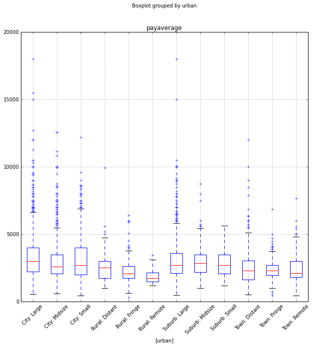

```python
df.boxplot('payaverage', by='urban', figsize=(10,10), rot=45)
```

```python
def f(x):
    if x.find("Urban") != -1:
        return "Urban"
    elif x.find("Suburban") != -1:
        return "Suburban"
    elif x.find("Rural") != -1:
        return "Rural"
    elif x.find("Town") != -1:
        return "Town"
    else:
        return np.nan
```

```python
if "Urban".find("Urb") != -1:
    print "True"
```

```
True
```

```python
def f(x):
    if str(x).find("City") != -1:
        return "Urban/Suburban"
    elif str(x).find("Suburb") != -1:
        return "Urban/Suburban"
    elif str(x).find("Rural") != -1:
        return "Rural/Town"
    elif str(x).find("Town") != -1:
        return "Rural/Town"
    else:
        return np.nan
df['urb'] = df.urban.apply(f)
```

```python
df['urb'].value_counts()
```

```
Urban/Suburban    5878
Rural/Town         998
dtype: int64
```

```python
len(df[df.payaverage < 2500])/float(len(df))
```

```
0.4202626641651032
```

```python
df[df.adv_degree.notnull()].adv_degree.value_counts(normalize=True)
```

```
MA/MS    0.595763
PhD      0.345102
None     0.044131
JD       0.013680
MD       0.001324
dtype: float64
```

```python
df[df.has_health_ins.notnull()].has_health_ins.value_counts(normalize=True)
```

```
False    0.797106
True     0.202894
dtype: float64
```